# Using a holistic health approach to achieve weight-loss maintenance: results from the Spirited Life intervention | Translational Behavioral Medicine | Oxford Academic

Skip to Main Content

Advertisement

[figure not shown]

[figure not shown]

Skip Nav Destination

Article Navigation

[figure not shown]

Volume 10

Issue 1

February 2020

### Article Contents

# Using a holistic health approach to achieve weight-loss maintenance: results from the Spirited Life intervention

[Rae Jean Proeschold-Bell](https://academic-oup-com.ezproxy.library.uvic.ca/tbm/article/10/1/223/5239983), [Dori M Steinberg](https://academic-oup-com.ezproxy.library.uvic.ca/tbm/article/10/1/223/5239983), [Jia Yao](https://academic-oup-com.ezproxy.library.uvic.ca/tbm/article/10/1/223/5239983), [David E Eagle](https://academic-oup-com.ezproxy.library.uvic.ca/tbm/article/10/1/223/5239983), [Timothy W Smith](https://academic-oup-com.ezproxy.library.uvic.ca/tbm/article/10/1/223/5239983), [Grace Y Cai](https://academic-oup-com.ezproxy.library.uvic.ca/tbm/article/10/1/223/5239983), [Elizabeth L Turner](https://academic-oup-com.ezproxy.library.uvic.ca/tbm/article/10/1/223/5239983)

*Translational Behavioral Medicine*, Volume 10, Issue 1, February 2020, Pages 223–233, https://doi-org.ezproxy.library.uvic.ca/10.1093/tbm/iby117

Published:

13 December 2018

## Abstract

Weight-loss maintenance is essential to sustain the health benefits of weight loss. Studies with lower intensity intervention supports under real-world conditions are lacking. This study examined changes in weight and cardiometabolic biomarkers among Spirited Life participants following initial 12-month weight loss at 12–24 months and 24–42 months. A total of 719 clergy received a wellness intervention, including a 10-week online weight-loss program in the first 12 months and monthly health coaching throughout 24 months. Mean changes in weight, blood pressure, high-density lipoproteins, and triglycerides were estimated using random effects linear models, accounting for repeated measures. Weight was additionally analyzed in subsamples stratified by body mass index (BMI). At baseline, 17.1% of participants had BMI < 25 kg/m<sup>2</sup> and 11.8% had BMI ≥ 40 kg/m<sup>2</sup>. Mean 12-month weight loss was −2.4 kg (95% CI: −2.8 kg, −2.1 kg). On average, at 42 months, participants regained weight but did not exceed baseline (−0.5 kg, 95% CI: −1.2 kg, 0.2 kg), improvements in triglycerides were completely sustained (−13.9 mg/dL, 95% CI: −18.6 mg/dL, −9.2 mg/dL), and systolic blood pressure improvements remained significant (−1.9 mmHg, 95% CI: −3.0 mmHg, −0.9 mmHg). Participants with a BMI ≥ 40 kg/m<sup>2</sup> lost significantly more weight that was sustained at 42 months (−5.8 kg, 95% CI: −8.9 kg, −2.7 kg). The Spirited Life wellness intervention produced weight loss and, for participants with higher levels of obesity, sustained weight-loss maintenance. The intervention was effective for long-term prevention of weight gain among participants with BMI of 25 to ≤40 kg/m<sup>2</sup>, through 42 months. Wellness interventions such as Spirited Life should be considered for adoption.

Implications

**Practice:** Long-duration, lower-intensity interventions that use a variety of ways to teach and practice behavior change strategies can create initial weight loss and prevent long-term weight gain among most participants, and sustain weight loss among those with higher levels of obesity.

**Policy:** Employers who want to prevent weight gain among employees in general, and induce and sustain weight loss among employees with higher levels of obesity, should consider engaging employees with an initial online weight-loss program, followed by low levels of support for relatively long periods of time (e.g., 2 years).

**Research:** Future research should determine the cost-benefit of offering weight loss and weight-loss maintenance programs to all versus some employees and determine the optimum length of intervention to maximize long-term health benefits.

## INTRODUCTION

Obesity is one of the largest global causes of preventable morbidity and mortality [[1](https://academic-oup-com.ezproxy.library.uvic.ca/tbm/article/10/1/223/5239983)]. This risk of morbidity and mortality decreases with weight loss [[2](https://academic-oup-com.ezproxy.library.uvic.ca/tbm/article/10/1/223/5239983)]. Standard behavioral weight-loss interventions, using lifestyle changes in diet and exercise habits, produce an average loss of 7%–10% of initial weight at 1 year [[3–5](https://academic-oup-com.ezproxy.library.uvic.ca/tbm/article/10/1/223/5239983)]. Yet, even small changes in body weight—losses of 3%–5% of initial body weight—can produce clinically meaningful improvements in health [[6](https://academic-oup-com.ezproxy.library.uvic.ca/tbm/article/10/1/223/5239983)]. Despite the efficacy of behavioral interventions for weight loss, many individuals who lose weight struggle to maintain improvements post-intervention [[7](https://academic-oup-com.ezproxy.library.uvic.ca/tbm/article/10/1/223/5239983)]. Maximum weight losses from behavioral interventions commonly occur at around 6 months, with participants gradually regaining their weight thereafter [[8](https://academic-oup-com.ezproxy.library.uvic.ca/tbm/article/10/1/223/5239983),[9](https://academic-oup-com.ezproxy.library.uvic.ca/tbm/article/10/1/223/5239983)]. If there is no emphasis on maintenance past 6 months, about half of participants will regain back to their starting weight; over a 2-year period posttreatment, most individuals regain one third to two thirds of the weight they lost, and some gain beyond their baseline weight [[10–13](https://academic-oup-com.ezproxy.library.uvic.ca/tbm/article/10/1/223/5239983)]. In the gold standard Look AHEAD trial, even 4 years after receiving a lifestyle intervention, about 50% of participants who lost between 5% and 10% regained close to or above starting weight [[14](https://academic-oup-com.ezproxy.library.uvic.ca/tbm/article/10/1/223/5239983)]. It is critically important to identify ways to support people in weight-loss maintenance [[15](https://academic-oup-com.ezproxy.library.uvic.ca/tbm/article/10/1/223/5239983)].

In addition, weight stability is now considered a health-promoting goal. U.S. adults from age 18 to 55 typically gain 0.5–1.0 kg per year [[16](https://academic-oup-com.ezproxy.library.uvic.ca/tbm/article/10/1/223/5239983)]. While it varies by age, studies on men suggest average weight gains of 0.18–0.29 kg per year [[16](https://academic-oup-com.ezproxy.library.uvic.ca/tbm/article/10/1/223/5239983),[17](https://academic-oup-com.ezproxy.library.uvic.ca/tbm/article/10/1/223/5239983)]. The 2013 obesity treatment guidelines from the American Heart Association, the American Academy of Cardiology, and The Obesity Society not only recommend weight loss for all overweight and obese individuals, but also state that individuals with obese or overweight status who are not interested in weight loss should focus on preventing weight gain [[6](https://academic-oup-com.ezproxy.library.uvic.ca/tbm/article/10/1/223/5239983)]. Importantly, weight stability can confer health benefits; some studies have shown that individuals who maintain their weight for upwards of 20 years can improve or keep stable cardiometabolic indicators, such as blood pressure, glucose, and lipid levels [[18](https://academic-oup-com.ezproxy.library.uvic.ca/tbm/article/10/1/223/5239983)].

Whether it be for weight loss, weight-loss maintenance, or weight stability, providing multifaceted support for lifestyle modification remains one of the most effective elements of a behavioral weight control intervention [[19](https://academic-oup-com.ezproxy.library.uvic.ca/tbm/article/10/1/223/5239983)]. Both the weight loss and weight-loss maintenance phases of obesity treatment emphasize skill building for behaviors such as portion control, relapse prevention, incorporating activities into one’s lifestyle, social support, and accountability. Yet, some strategies do differ when entering the maintenance phase of a behavioral weight control intervention [[20](https://academic-oup-com.ezproxy.library.uvic.ca/tbm/article/10/1/223/5239983)]. The National Weight Control Registry indicates that successful maintainers weigh frequently, stay consistent with their eating pattern, and exercise at levels higher than what is typically promoted for weight loss [[21](https://academic-oup-com.ezproxy.library.uvic.ca/tbm/article/10/1/223/5239983)]. Efficacy trials testing interventions for weight-loss maintenance incorporating these strategies have shown positive results [[10](https://academic-oup-com.ezproxy.library.uvic.ca/tbm/article/10/1/223/5239983),[22](https://academic-oup-com.ezproxy.library.uvic.ca/tbm/article/10/1/223/5239983)]. For example, in the STOP Regain trial, which emphasized daily weighing as the main self-regulation strategy, Wing and colleagues (2006) found that fewer participants who received support via face-to-face meetings regained weight compared to those who received no support; however, support via digital channels was effective at preventing regain as well, albeit less effective compared to face-to-face [[22](https://academic-oup-com.ezproxy.library.uvic.ca/tbm/article/10/1/223/5239983)]. Similarly, Svetkey et al. [[10](https://academic-oup-com.ezproxy.library.uvic.ca/tbm/article/10/1/223/5239983)] compared an intervention of monthly personal contact versus an interactive technology-based intervention versus a self-directed control arm; both intervention arms focused on motivation, self-monitoring, problem-solving, and support for 30 months. At 30 months post-intervention, the personal-contact group weighed 1.2 kg less than the interactive technology-based group, although even the technology-based group outperformed the self-directed control group at 18 months. These results suggest that intensive support is most effective for preventing regain and maintaining weight loss; however, even minimal support with a lighter touch for weight maintenance can be effective. A lighter touch intervention (e.g., less in-person contact and fewer minutes per month than, for example, the Look AHEAD intervention [[14](https://academic-oup-com.ezproxy.library.uvic.ca/tbm/article/10/1/223/5239983)]) can be less burdensome to participants and has greater potential to be implemented in real-world settings [[23](https://academic-oup-com.ezproxy.library.uvic.ca/tbm/article/10/1/223/5239983)].

The workplace offers a means of reaching people for weight loss and weight gain prevention interventions, in a setting where people can support each other’s efforts [[24](https://academic-oup-com.ezproxy.library.uvic.ca/tbm/article/10/1/223/5239983)]. However, it is unclear whether lighter touch workplace interventions can lead to long-term outcomes. In one large-scale trial of hotel employees that provided group sessions (mean attendance = 5.4) and supportive messages in the workplace for almost a year, weight loss was not significantly different at 12 or 24 months [[25](https://academic-oup-com.ezproxy.library.uvic.ca/tbm/article/10/1/223/5239983)]. Other lighter touch workplace interventions have similarly produced null effects [[26](https://academic-oup-com.ezproxy.library.uvic.ca/tbm/article/10/1/223/5239983)].

We conducted a pragmatic behavioral intervention trial called Spirited Life. It included lighter touch weight intervention components among an occupational group and its goals were to decrease metabolic syndrome, produce weight loss at 12 months among those who were overweight or obese, maintain weight loss through and beyond the 2-year intervention period, and prevent weight gain among participants of normal weight. The intervention combined evidence-based components with some innovations (see [Fig. 1](https://academic-oup-com.ezproxy.library.uvic.ca/tbm/article/10/1/223/5239983)). Participants of all weight statuses were encouraged to sign up for a 10-week, online, weight-loss program called Naturally Slim that emphasized eating only when hungry; decreasing sugar intake; eating smaller portions; and balancing fats, proteins, and carbohydrates. Naturally Slim did not have a rigorous evidence base. The company shared with us findings from hospital groups that enrolled highly motivated patients who evidenced weight-loss maintenance and metabolic syndrome reduction several years post-intervention based on medical record data, but with no control group or adjustment for loss to follow-up [[27](https://academic-oup-com.ezproxy.library.uvic.ca/tbm/article/10/1/223/5239983)]. However, Naturally Slim’s nutritional, portion control, and accountability approaches were consistent with weight-loss recommendations [[19](https://academic-oup-com.ezproxy.library.uvic.ca/tbm/article/10/1/223/5239983)] and had the added advantage of being scalable for a dispersed group. To this online intervention, we offered follow-up support through up-to-monthly phone health coaching sessions. Health coaches utilized motivational interviewing, which has a strong evidence base for a wide range of behavior changes [[28–32](https://academic-oup-com.ezproxy.library.uvic.ca/tbm/article/10/1/223/5239983)]. They encouraged participants to set their own health goals, which could involve physical health, mental health, spiritual well-being, or all three. For weight loss, health coaches focused on the Naturally Slim weight-loss strategies, and for weight-loss maintenance they revisited these health strategies plus continued to engage in goal-setting and motivational interviewing techniques. Health coaching has been shown to be effective for weight loss and related health behaviors [[33–38](https://academic-oup-com.ezproxy.library.uvic.ca/tbm/article/10/1/223/5239983)].

Fig 1

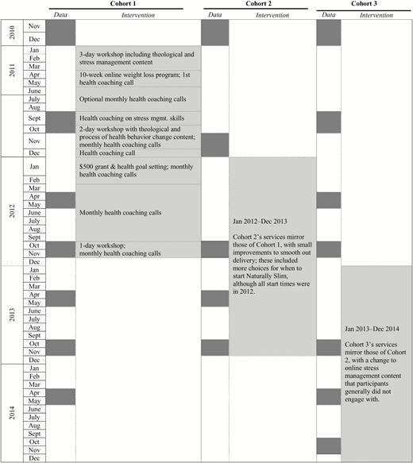

[Open in new tab](https://academic-oup-com.ezproxy.library.uvic.ca/view-large/figure/204686596/iby11701.jpg)Download slide

| Spirited Life intervention components by month and cohort. “Data” indicates data collection, which always included a survey and an in-person cardiometabolic screening.

[figure not shown]

[output not shown]

One way in which we intended the intervention to be innovative was in its long duration of 24 months; we wanted time to allow participants to change behaviors, slip up in the course of normal life fluctuations (e.g., change in seasons, work expectations, family life), and still have support to return to healthy practices [[39](https://academic-oup-com.ezproxy.library.uvic.ca/tbm/article/10/1/223/5239983)]. We built in three components to engage participants in such a long intervention that was also sporadic in that participants did not need to set aside regular time, for example in the way weight-loss groups require. One component for ongoing engagement was monthly health coaching. Another was punctuating the intervention with in-person workshops, which occurred at the beginning, middle, and end of the 2 years. For this clergy population, each workshop included theological reasons to attend to one’s health and were packaged in ways to resonate with clergy (e.g., morning prayer, communion). The first workshop focused on initial motivation to lose weight and make other holistic health behavior changes. The second and third workshops sought to maintain weight loss, with content focused on motivating additional behavior change, promoting health behavior self-efficacy through teaching the process of behavior change, and providing opportunities for participants to articulate core values, re-commit to behavior change, and plan for sustaining their accomplishments. The third component was offering participants $500 grants 1 year into the intervention to assist them in meeting health goals and to maintain their motivation; we also considered this a means of promoting weight-loss maintenance. At the time, there was not evidence of the efficacy of financial incentives for weight-loss maintenance [[40](https://academic-oup-com.ezproxy.library.uvic.ca/tbm/article/10/1/223/5239983),[41](https://academic-oup-com.ezproxy.library.uvic.ca/tbm/article/10/1/223/5239983)], although anecdotally health insurance companies were considering them.

The Spirited Life intervention had other components less relevant to the current study and described elsewhere [[39](https://academic-oup-com.ezproxy.library.uvic.ca/tbm/article/10/1/223/5239983)]. They included stress management content, although there was no evidence in the 2-year outcomes that stress symptoms had improved. They also included targeting people who interact with each other and who might provide mutual support or be influenced by a change in social norms. Although we did not measure it specifically, there was anecdotal evidence that clergy talked to each other about weight-loss strategies and noticed weight loss in each other. Many participants commented that they felt a shift in climate toward self-care being more acceptable for clergy.

We invited all United Methodist clergy in North Carolina (NC) to participate, irrespective of current health status. We included normal-weight clergy consistent with a selective prevention strategy [[42](https://academic-oup-com.ezproxy.library.uvic.ca/tbm/article/10/1/223/5239983)]. Christian clergy are in great need of weight loss and metabolic syndrome reduction programs. Across multiple denominations, the prevalence of obesity in U.S. Christian clergy is estimated to be 39% to 43% [[43–48](https://academic-oup-com.ezproxy.library.uvic.ca/tbm/article/10/1/223/5239983)]. In a previous study with this population, we found the obesity prevalence was 10.3 percentage points higher than the surrounding comparable population [[43](https://academic-oup-com.ezproxy.library.uvic.ca/tbm/article/10/1/223/5239983)]. These same studies found high rates of chronic disease among clergy. In our Spirited Life study, 50.9% met criteria for metabolic syndrome [[49](https://academic-oup-com.ezproxy.library.uvic.ca/tbm/article/10/1/223/5239983)].

The Spirited Life study aims were to: (a) for participants overweight or obese at baseline, promote initial weight loss and reversal of metabolic syndrome components (central obesity, elevated triglycerides, low high-density lipoproteins, hypertension, and elevated blood glucose) [[50](https://academic-oup-com.ezproxy.library.uvic.ca/tbm/article/10/1/223/5239983)]; (b) for participants overweight or obese at baseline, maintain weight loss and reversal of metabolic syndrome components for at least 18 months post-intervention; and (c) for participants with normal weight at baseline, promote healthy weight stability. The intervention lasted 24 months. We randomly assigned participants to one of three cohorts: immediate intervention, 1-year waitlist cohort, and 2-year waitlist cohort. After the intervention, we followed two of the three cohorts for an additional 18 months.

After 2 years, intention-to-treat analyses revealed significant reductions in weight, averaging −1.7 kg to −3.0 kg, depending on intervention cohort [[49](https://academic-oup-com.ezproxy.library.uvic.ca/tbm/article/10/1/223/5239983)]. The 505 participants who were obese at baseline evidenced an estimated intervention effect of 1.8 kg (95% CI: 0.01 kg, 3.62 kg) greater weight loss compared with control participants. These levels of weight loss are modest, but consistent with effectiveness trials conducted in real-world settings [[51](https://academic-oup-com.ezproxy.library.uvic.ca/tbm/article/10/1/223/5239983)]. In addition to weight loss, the prevalence of metabolic syndrome in Spirited Life was 12% lower at the end of the 2-year intervention.

In this article, we examine the impact of the Spirited Life intervention on weight-loss maintenance after initial weight loss but during low-intensity intervention (months 12–24), and after the intervention (months 24–42), as well as on long-term changes in cardiometabolic biomarkers (e.g., blood pressure) impacted by weight. We further examine long-term weight stability in normal-weight participants.

## METHODS

### Procedure

We have described Spirited Life trial methods in a protocol article [[39](https://academic-oup-com.ezproxy.library.uvic.ca/tbm/article/10/1/223/5239983)] and reported on 2-year outcomes covering the intervention period [[49](https://academic-oup-com.ezproxy.library.uvic.ca/tbm/article/10/1/223/5239983)]. Briefly, we contacted all clergy who were members in July 2010 of the NC and Western NC Conferences of the United Methodist Church (UMC). These two governing bodies employ roughly 1,800 clergy. We invited individuals based on clergy occupation status rather than health status. There were intentionally few exclusion criteria (e.g., being on leave, seminary professors, hospital chaplains).

Of the 1,745 clergy invited to participate in the trial, 1,114 (64%) clergy consented and provided survey and in-person cardiometabolic screening data in fall 2010. We randomly assigned these participants to three cohorts: the immediate intervention cohort (Cohort 1), a 1-year waitlist intervention cohort (Cohort 2), and a 2-year waitlist intervention cohort (Cohort 3). Only 49 participants received the intervention in a cohort different from their random assignment. Each cohort received 2 years of intervention, with Cohort 1 starting in 2011, Cohort 2 in 2012, and Cohort 3 in 2013. The timing enabled Cohort 3 to serve as a waitlist control group to Cohort 1 for the 2-year outcomes paper.

We conducted cardiometabolic screenings with each of the cohorts immediately prior to intervention (0 months, called “baseline” in this article) and at 12, 18, and 24 months of intervention. Cohorts 1 and 3 had additional measurements at 30, 36, and 42 months (i.e., 6, 12, and 18 months after intervention completion). Post-intervention data were not collected from Cohort 2. Although study blinding was not possible (participants knew when they received the intervention), the cardiometabolic screening assessors were blinded to cohort.

Duke University’s Arts & Sciences Institutional Review Board (IRB) approved all procedures. Study participants gave free and informed consent.

### Measures

Staff measured height, weight, high-density lipoproteins, and triglycerides, as well as systolic and diastolic blood pressure, using detailed protocols (available upon request). We measured height to the nearest 0.25 inch using a Seca 213 stadiometer, and weight to the nearest 0.2 lb. on a calibrated digital scale (Seca 876), with the participant removing heavy clothing and shoes prior to being weighed. We created body mass index (BMI) categories using the National Heart, Lung, and Blood Institute definition (NHLBI Expert Panel, 1998) [[52](https://academic-oup-com.ezproxy.library.uvic.ca/tbm/article/10/1/223/5239983)].

We collected blood samples via finger sticks for lipid tests. High-density lipoproteins and triglycerides values were measured by the Cholestech LDX system. We asked participants to fast for at least 9 hours prior to data collection. After a 5-minute resting period, blood pressure was assessed three times on the right arm using an Omron HEM-907XL machine, with a 30-second rest between measurements. Throughout, participants remained seated with feet flat on the floor and arm resting at heart level. We took means of the three resting systolic and diastolic blood pressure values, respectively, for analysis. Staff recorded cardiometabolic data on paper then double-entered the data. We performed consistency checks across time periods to create a reliable final database.

### Analyses

In the current analyses, we used the cohort in which participants ultimately received the intervention, allowing the analyses to accurately reflect the number of elapsed months since the end of the intervention. With our focus on post-intervention outcomes, the current analysis could only use: (a) data immediately before intervention and during intervention from all individuals and (b) post-intervention data from individuals who received the intervention with Cohorts 1 and 3 [[39](https://academic-oup-com.ezproxy.library.uvic.ca/tbm/article/10/1/223/5239983)]. These post-intervention data were then referenced against baseline data immediately prior to intervention receipt. There were a total of 719 participants who received the intervention in Cohorts 1 and 3. (See Supplement for sample size details.)

Health outcomes of interest, all continuous, were weight, percentage body weight change, high-density lipoproteins (for the entire sample and separately for males and females given different recommended levels by gender), systolic blood pressure, diastolic blood pressure, and triglycerides. We fitted a piecewise random effects linear regression model separately to each health outcome by regressing the outcome on three pieces of intervention (the first year in intervention, the second year in intervention, and the 18 months post-intervention) and on cohort (a 2-level factor coded as a variable indicating Cohort 1, with Cohort 3 as the reference level to allow for possible period effects due to different intervention starting time points). To account for correlation over time due to repeated measurements on the same individual, we included correlated random intercepts and random slopes which allowed for decreasing correlation of measurements further apart in time. Different random slopes were specified for each of the three time periods of the model to mirror the three-piece fixed effects model for time. We specified residual errors that were independent and normally distributed. Because triglycerides were both left-censored due to a lower limit of detection and right-censored due to a higher limit of detection, we fitted a Tobit piecewise random effects model for this outcome, in which three pieces of intervention and correlated random intercepts were included. We analyzed outcomes in the entire sample and in stratified samples by baseline BMI category (<25; 25 to <30; 30 to <40; and ≥40 kg/m<sup>2</sup>).

For each health outcome, we reported model-based estimates of the rate of change per year over each of the three pieces of intervention. We also obtained model-based estimates of mean change for each outcome from baseline to 18 months post-intervention (0–42 months), given our interest in determining whether weight loss can be maintained long-term. Standardized effect sizes for the primary outcome (weight) were obtained by scaling the mean weight changes (and their 95% CI) by the model-estimated residual standard deviation. All analyses were performed using Stata v15.1 software [[53](https://academic-oup-com.ezproxy.library.uvic.ca/tbm/article/10/1/223/5239983)].

As in all follow-up studies, some participants missed data at some measurement time points, either because they dropped out of the study or because they were unable to attend the measurement visit. To ascertain whether the participants who had missing outcome data at a follow-up time point were different from those who were not missing at the same time point, we compared their baseline characteristics. Cohort, age, marital status, and education level were predictive of missing the primary outcome (weight) at follow-up; baseline weight and very low triglycerides values (≤45 mg/dL) at baseline had a trend of being predictive of missing weight at follow-up. In a sensitivity analysis to account for these identified predictors of missing outcome data, we adjusted for these covariates in our models of weight and percentage body weight change and then compared the results with our primary results; there were no substantive differences. Because the random effects linear regression modeling approach we used is likelihood-based, under an assumption of outcome data being missing-at-random (MAR) conditional on the identified covariates, the results from our sensitivity analyses provide valid estimates of changes over time, adjusting for the missing data pattern.

In another sensitivity analysis, participants who received the intervention with Cohort 2 were included in order to provide additional information on outcome levels during the intervention, although they provide no information on post-intervention outcome levels. This sensitivity analysis found that the inclusion of data from Cohort 2 did not substantially alter the trends in findings.

The trial did not include a control group for time points beyond 2 years; we therefore wondered how the weight changes seen in Spirited Life participants would have compared to weight changes observed in those clergy who declined to enroll in the Spirited Life trial. In supportive analyses, we used data from a longitudinal panel survey conducted by our team with the same NC UMC clergy population. We were able to compare self-reported weight at 2 and 4 years following the start of the Spirited Life intervention between clergy who did and did not enroll in the trial. We elaborate the methods and results in the Supplement.

## RESULTS

Spirited Life participants followed post-intervention (*n* = 719, i.e., Cohorts 1 and 3) were primarily male (69.0%), white (89.6%), and married (90.1%), with a mean age of 52.7 (SD = 10.0 years) (see [Table 1](https://academic-oup-com.ezproxy.library.uvic.ca/tbm/article/10/1/223/5239983)). All participants were employed by the UMC at the time of enrollment; at the start of the intervention, 98.3% reported having health insurance.

Table 1

| Baseline characteristics of the study participants (*N* = 719)

| Characteristics | % (*n*/*N*) or M (SD), *n* |
| --- | --- |
| Gender, % (*n*/*N*) |  |
| Male | 69.0% (496/719) |
| Female | 31.0% (223/719) |
| Age, M (SD), *N* | 52.7 (10.0), 719 |
| Race, % (*n*/*N*) |  |
| White | 89.6% (644/719) |
| Black | 6.0% (43/719) |
| Other | 4.5% (32/719) |
| Marital status,<sup>a</sup> % (*n*/*N*) |  |
| Married | 90.1% (647/718) |
| Not married | 9.9% (71/718) |
| Education,<sup>a</sup> % (*n*/*N*) |  |
| College and below | 15.3% (110/718) |
| Master’s degree | 71.7% (515/718) |
| Doctoral degree | 13.0% (93/718) |
| Health insurance,<sup>a</sup> % (*n*/*N*) |  |
| Insured | 98.3% (707/719) |
| Not insured | 1.7% (12/719) |
| Financial stress,<sup>a</sup> % (*n*/*N*) |  |
| High stress | 17.8% (128/718) |
| Moderate or low | 82.2% (590/718) |
| Weight in KG, M (SD), *N* | 93.8 (23.3), 719 |
| BMI categories, % (*n*/*N*) |  |
| BMI < 25 | 17.1% (123/719) |
| 25 ≤ BMI < 30 | 34.4% (247/719) |
| 30 ≤ BMI < 40 | 36.7% (264/719) |
| BMI ≥ 40 | 11.8% (85/719) |
| Metabolic syndrome, % (*n*/*N*) | 34.7% (249/717) |
| High-density lipoproteins, M (SD), *N* | 45.9 (15.4), 713 |
| High-density lipoproteins in males | 40.9 (12.5), 491 |
| High-density lipoproteins in females | 56.9 (15.5), 222 |
| Systolic blood pressure, M (SD), *N* | 124.3 (14.6), 717 |
| Diastolic blood pressure, M (SD), *N* | 77.8 (10.2), 717 |
| Triglycerides |  |
| Low triglycerides (<45), % (*n*/*N*) | 3.2% (23/712) |
| Triglycerides values (≥45), M (SD), *N* | 141.6 (82.6), 689/712 |
| Intervention-based cohort, % (*n*/*N*) |  |
| Cohort 1: Immediate intervention | 49.5% (356/719) |
| Cohort 3: Two-year waitlist | 50.5% (363/719) |

<sup>a</sup>Missing demographical values are filled using values from the two other years. This was true for marital status (*n* = 23), education (*n* = 8), health insurance (*n* = 24), and financial stress (*n* = 25).

[Open in new tab](https://academic-oup-com.ezproxy.library.uvic.ca/view-large/204686621)

[output not shown]

[output not shown]

Table 2

| Results of modeling Spirited Life health outcomes during and after intervention

| Weight outcomes | Percentage of baseline weight, all (*N* = 719) | Weight, kg, all (*N* = 719) | Weight, kg, BL BMI < 25 (*N* = 123) | Weight, kg, 25 ≤ BL BMI < 30 (*N* = 247) | Weight, kg, 30 ≤ BL BMI < 40 (*N* = 264) | Weight, kg, BL BMI ≥ 40 (*N* = 85) |
| --- | --- | --- | --- | --- | --- | --- |
| Rate of change in outcome per year |  |  |  |  |  |  |
| 0–12 mths (int) | −2.40 [−2.73, −2.08]; *p* < .001 | −2.40 [−2.75, −2.06]; *p* < .0.001 | −0.07 [−0.51, 0.37]; *p* = .749 | −2.12 [−2.55, −1.69]; *p* < .0.001 | −3.05 [−3.64, −2.45]; *p* < .0.001 | −4.59 [−6.23, −2.95]; *p* < .0.001 |
| 12–24 mths (int) | 1.16 [0.72, 1.60]; *p* < .0.001 | 0.93 [0.53, 1.34]; *p* < .0.001 | 0.92 [0.41, 1.44]; *p* < .0.001 | 0.98 [0.48, 1.47]; *p* < .0.001 | 1.18 [0.52, 1.84]; *p* < .0.001 | 0.19 [−1.98, 2.36]; *p* = .865 |
| 24–42 mths (post int) | 0.93 [0.43, 1.43]; *p* < .0.001 | 0.67 [0.31, 1.02]; *p* < .0.001 | 0.57 [0.11, 1.04]; *p* = .016 | 0.91 [0.35, 1.46]; *p* = .001 | 1.00 [0.42, 1.58]; *p* < .0.001 | −0.91 [−2.74, 0.92]; *p* = .329 |
| Overall change |  |  |  |  |  |  |
| 0–42 mths | 0.15 [−0.93, 1.22]; *p* = .788 | −0.47 [−1.15, 0.20]; *p* = .171 | 1.71 [0.66, 2.75]; *p* = .001 | 0.22 [−0.88, 1.31]; *p* = .695 | −0.36 [−1.47, 0.75]; *p* = .525 | −5.76 [−8.85, −2.67]; *p* < .0.001 |
| Other health outcomes | HDL, mg/dL, all (*N* = 719) | HDL, mg/dL, males (*N* = 496) | HDL, mg/dL, females (*N* = 223) | Systolic blood pressure, mmHg (*N* = 719) | Diastolic blood pressure, mmHg (*N* = 719) | Triglycerides, mg/dL (*N* = 713) |
| Rate of change in outcome per year |  |  |  |  |  |  |
| 0–12 mths (int) | −0.86 [−1.49, −0.23]; *p* = .008 | −0.45 [−1.16, 0.25]; *p* = .207 | −1.80 [−3.09, −0.51]; *p* = .006 | −3.75 [−4.63, −2.87]; *p* < .0.001 | −2.01 [−2.59, −1.44]; *p* < .0.001 | −14.64 [−19.28, −10.01]; *p* < .0.001 |
| 12–24 mths (int) | 2.21 [1.50, 2.92]; *p* < .0.001 | 1.54 [0.79, 2.28]; *p* < .0.001 | 3.68 [2.13, 5.22]; *p* < .0.001 | 1.82 [0.90, 2.75]; *p* < .0.001 | 0.51 [−0.12, 1.13]; *p* = .113 | 2.36 [−2.36, 7.08]; *p* = .327 |
| 24–42 mths (post int) | −0.55 [−1.00, −0.10]; *p* = .016 | −0.22 [−0.72, 0.29]; *p* = .400 | −1.29 [−2.21, −0.38]; *p* = .006 | −0.01 [−0.71, 0.70]; *p* = .985 | 0.56 [0.11, 1.01]; *p* = .016 | −1.09 [−4.37, 2.18]; *p* = .513 |
| Overall change |  |  |  |  |  |  |
| 0–42 mths | 0.52 [−0.20, 1.25]; *p* = .157 | 0.76 [0.00, 1.52]; *p* = .049 | −0.06 [−1.64, 1.53]; *p* = .942 | −1.94 [−2.99, −0.88]; *p* < .0.001 | −0.67 [−1.38, 0.04]; *p* = .065 | −13.92 [−18.62, −9.22]; *p* < .0.001 |

Independent variables are intervention levels in three pieces and the cohort dummy variable. Coefficient, 95% confidence interval, and *p* value are reported. Overall changes are estimated using linear combinations of the model parameters.